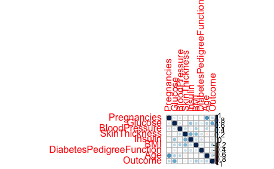

From the correlation matrix, we can see that some of the independent variables are moderately correlated, such as (Age, Pregnancy). This is the result of multicollinearity.

```
[1] FALSE
```

```
  Pregnancies        Glucose            BP
 Min.   : 0.000   Min.   :  0.0   Min.   :  0.00
 1st Qu.: 1.000   1st Qu.: 99.0   1st Qu.: 62.00
 Median : 3.000   Median :117.0   Median : 72.00
 Mean   : 3.845   Mean   :120.9   Mean   : 69.11
 3rd Qu.: 6.000   3rd Qu.:140.2   3rd Qu.: 80.00
 Max.   :17.000   Max.   :199.0   Max.   :122.00
       ST           Insulin           BMI
 Min.   : 0.00   Min.   :  0.0   Min.   : 0.00
 1st Qu.: 0.00   1st Qu.:  0.0   1st Qu.:27.30
 Median :23.00   Median : 30.5   Median :32.00
 Mean   :20.54   Mean   : 79.8   Mean   :31.99
 3rd Qu.:32.00   3rd Qu.:127.2   3rd Qu.:36.60
 Max.   :99.00   Max.   :846.0   Max.   :67.10
      DPF              Age        Outcome
 Min.   :0.0780   Min.   :21.00   0:500
 1st Qu.:0.2437   1st Qu.:24.00   1:268
 Median :0.3725   Median :29.00
 Mean   :0.4719   Mean   :33.24
 3rd Qu.:0.6262   3rd Qu.:41.00
 Max.   :2.4200   Max.   :81.00
```

Unbalanced distribution, which means about 65% people in this dataset did not have diabetes.

Given the Y(outcome) variable is categorical, we would need to use the logistic regression model.

Using undersampling to reduce bias towards the majority.

```
Training
  0   1
215 215
```

```
Testing
 0  1
53 53
```

```
[1] "train sample size:  430"
[1] "test sample size:  106"
```

```
  0   1
215 215

 0  1
53 53
```

Generalized Linear Model

Logistic Regression

Using Logit:

```
Call:
glm(formula = Outcome ~ Pregnancies + Glucose + BP + Insulin +
    BMI + DPF, family = binomial, data = diabetes.training)

Deviance Residuals:
     Min        1Q    Median        3Q       Max
-2.62967  -0.77467  -0.00394   0.74449   2.49059

Coefficients:
             Estimate Std. Error z value Pr(>|z|)
(Intercept) -8.652650   0.975204  -8.873  < 2e-16 ***
Pregnancies  0.112888   0.036176   3.121  0.00181 **
Glucose      0.043847   0.005226   8.391  < 2e-16 ***
BP          -0.011034   0.006527  -1.691  0.09090 .
Insulin     -0.002244   0.001188  -1.889  0.05884 .
BMI          0.093810   0.018709   5.014 5.33e-07 ***
DPF          1.174248   0.408298   2.876  0.00403 **
---
Signif. codes:
0 ‘***’ 0.001 ‘**’ 0.01 ‘*’ 0.05 ‘.’ 0.1 ‘ ’ 1

(Dispersion parameter for binomial family taken to be 1)

    Null deviance: 596.11  on 429  degrees of freedom
Residual deviance: 420.64  on 423  degrees of freedom
AIC: 434.64

Number of Fisher Scoring iterations: 5
```

The logistic regression coefficients give the change in the log odds of the outcome for a one unit increase in the predictor variable.

The maximum likelihood estimation can be expressed as:

$$\ln{\frac{\pi}{1 - \pi}} = -8.653 +
0.113X_{1} + 0.0438X_{2} - 0.0110X_{3} - 0.00224X_{4} + 0.0938X_{5} +
1.174X_{6}$$

```
 (Intercept)  Pregnancies      Glucose           BP
0.0001746633 1.1195063089 1.0448228817 0.9890262174
     Insulin          BMI          DPF
0.9977580760 1.0983514914 3.2357073370
```

Interpretation of step model:

- For every one unit increase in pregnancies, there is an increase change in $(1.12 - 1)*100 = 12%$% in odds ratio
- For every one unit increase in glucose, there is an increase change in $(1.04 - 1)*100 = 4%$% in odds ratio
- For every one unit increase in BP, there is decrease change of $1.1%$% in odds ratio
- For every one unit increase in Insulin, there is decrease change of $0.2%$% in odds ratio
- For every one unit increase in BMI, there is an increase change of $9.8%$% in odds ratio
- For every one unit increase in DPF, there is an increase change in $223%$% in odds ratio

Statistical Inference:

```
                    2.5 %        97.5 %
(Intercept) -10.661396815 -6.8305781742
Pregnancies   0.042934892  0.1850905192
Glucose       0.034050919  0.0545833314
BP           -0.024241189  0.0014660677
Insulin      -0.004577926  0.0001009734
BMI           0.058577154  0.1320329987
DPF           0.386484226  1.9891902599
```

Prediction:

```
          pred.classes
           Pred. neg Pred. pos
  Obs. neg        43        10
  Obs. pos        21        32
```

Average Predicted Probability:

```
[1] 0.6150265
```

Accuracy of the step-wise multiple Logistic Regression Model:

```
[1] 0.7075472
```

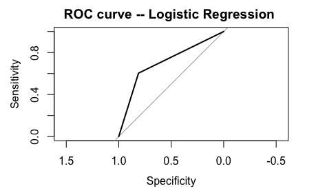

```
Call:
roc.formula(formula = diabetes.testing$Outcome ~ pred.classes)

Data: pred.classes in 53 controls (diabetes.testing$Outcome 0) < 53 cases (diabetes.testing$Outcome 1).
Area under the curve: 0.7075
```

Given the plot and AUC, the value 0.7075 indicates that this is a good predictive model.